## Python Training Package Designed by Kwan Lee

# This training package is internal use to train beginners based on contents of w3schools.org

**Slide 1: Introduction**

# Preparing the environments for Python Training

**Slide 2: Environment Setup**

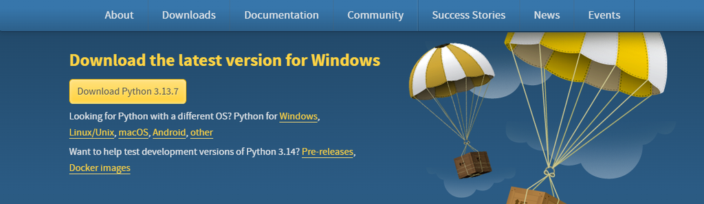

## Step 1: Download Python Package from Python.org

- From your browser type "www.python.org"
- Click the "Downloads" in the menu bar
- Click the Download Python 3.13.7 button
- This will download python package into your computer

# steps before excercise the jupyter notebook

**Slide 3: Environment Setup**

1. Select Kernel (The button is at the top right corner) click the button: a pop up window will appear at the top center with "Python Environments" click the "Python Environment" : list of options to select "python environment" move the mouse to the python version you want to use (ex: Python 3.xx.x)

```python
import sys
import os

print(sys.version)
```

```
3.13.6 (tags/v3.13.6:4e66535, Aug  6 2025, 14:36:00) [MSC v.1944 64 bit (AMD64)]
```

```python
print("Hello")
```

```
Hello
```

```python
if 5 > 2:
    print("5 is greater than 2")
```

```
5 is greater than 2
```

```python
# This is comment

x = 5  # x is a variable
print(x) # this prints the value of x
print("x")  # this is a string
```

```
5
x
```

## Creating Variables

Python has no command for declaring a variable.

A variable is created the moment you first assign a value to it.

## Slide Navigation Tips

- **Main Slides**: Each major section (Introduction, Setup, Variables, etc.)
- **Sub-slides**: Code examples and detailed explanations
- **Navigation**:
  - Use arrow keys: ← → for main slides, ↑ ↓ for sub-slides
  - Space bar to advance
  - Escape to exit slideshow mode

```python
# Examples
x = 5
y = "John"
print(x)
print(y)
```

```
5
John
```

```python
# Casting
# If you want to specify the data type of a variable, this can be done with casting.
x = str(5)
y = int(5)
z = float(5)
total = y + z
print(total)
```

```
10.0
```

```python
# Get the type of variables

x = 5
y = "John"
print(type(x))
print(type(y))
```

```
<class 'int'>
<class 'str'>
```

## Variable Names

A variable can have a short name (like x and y) or a more descriptive name (age, carname, total_volume).

Rules for Python variables:

A variable name must start with a letter or the underscore character A variable name cannot start with a number A variable name can only contain alpha-numeric characters and underscores (A-z, 0-9, and _ ) Variable names are case-sensitive (age, Age and AGE are three different variables) A variable name cannot be any of the Python keywords.

```python
# Examples of variable assignment

myvar = "John"
my_var = "John"
_my_var = "John"
myVar = "John"
MYVAR = "John"
myvar2 = "John"

_12345 = "John"  # even numbers preceding with "_" is allowed
print(_12345)
```

```
John
```

```python
# Illegal variable names

2myvar = "John"
my-var = "John"
my var = "John"
```

```
  Cell In[63], line 3
    2myvar = "John"
    ^
SyntaxError: invalid decimal literal
```

## Assign Multiple variables

Python allows you to assign values to multiple variables in one line:

```python
x, y, z = "Orange", "Banana", "Cherry"
print(x)
print(y)
print(z)
```

```
Orange
Banana
Cherry
```

```python
x = y = z = "Orange"
print(x)
print(y)
print(z)
```

```
Orange
Orange
Orange
```

```python
# Unpack Collections
fruits = ["apple", "banana", "cherry"]
x, y, z = fruits
print(x)
print(y)
print(z)
```

```
apple
banana
cherry
```

```python
fruits = ["apple", "banana", "cherry"]
x, y, z = fruits[0], fruits[1], fruits[2]
print(x)
print(y)
print(z)
```

```
apple
banana
cherry
```

## Output Variables

The Python print() function is often used to output variables.

```python
x = "Python is awesome"
print(x)
```

```
Python is awesome
```

```python
x = "Python"
y = "is"
z = "awesome"
print(x, y, z)
```

[output not shown]

```python
# Concatenate Variables
x = "Python "
y = "is "
z = "awesome"
print(x + y + z)
```

```
Python is awesome
```

```python
x = 5
y = 10
print(x + y)
```

```
15
```

```python
x = "5"
y = "10"
print(x + y)
```

```
510
```

```python
x = 5
y = "John"
print(x + y)
```

[output not shown]

```python
x = 5
y = "John"
print(x, y)
```

```
5 John
```

# Global Variables

Variables that are created outside of a function (as in all of the examples in the previous pages) are known as global variables.

Global variables can be used by everyone, both inside of functions and outside.

```python
# Create a variable outside of a function, and use it inside the function

x = "awesome"

def myfunc():
  print("Python is " + x)

myfunc()
```

```
Python is awesome
```

```python
myfunc()
```

```
Python is awesome
```